# Определение возраста покупателей

Сетевой супермаркет внедряет систему компьютерного зрения для обработки фотографий покупателей. Фотофиксация в прикассовой зоне поможет определять возраст клиентов, чтобы:

- Анализировать покупки и предлагать товары, которые могут заинтересовать покупателей этой возрастной группы;
- Контролировать добросовестность кассиров при продаже алкоголя.

Цель исследования — построить модель, которая по фотографии определит приблизительный возраст человека.

В нашем распоряжении набор фотографий людей с указанием возраста. Данные взяты с сайта ChaLearn Looking at People.

Исследование пройдёт в три этапа:

- Исследовательский анализ данных
- Обучение модели
- Анализ обученной модели

## Исследовательский анализ данных

```python
# Импорт необходимых библиотек


import pandas as pd
import matplotlib.pyplot as plt
import seaborn as sns
import numpy as np

from tensorflow.keras.layers import Dense, GlobalAveragePooling2D
from tensorflow.keras.models import Sequential
from tensorflow.keras.optimizers import Adam
from tensorflow.keras.preprocessing.image import ImageDataGenerator
from tensorflow.keras.applications.resnet import ResNet50
```

```python
# Константы


r_seed = 12345
```

```python
# Функции и классы


# Функция для получения общих сведений о данных

def data_info(title, data):

    print('Общие сведения "{}":'.format(title))
    print()

    data.info()

    print()
    print()

    print('Пример данных (случайные 5 строк):')
    display(data.sample(5, random_state=r_seed))

    print()
    print()

    print('Количество пропусков по столбцам:')
    print()
    for col in data.columns:
        nmv = data[col].isna().sum()
        pmv = nmv/len(data)

        if pmv == 0:
            print('\033[0m{} - {} шт. - {:.2%}'.format(col, nmv, pmv))
        elif pmv <= 0.1:
            print('\033[0m{} - \033[43m{} шт.\033[0m - \033[43m{:.2%}'.format(col, nmv, pmv))
        else:
            print('\033[0m{} - \033[41m{} шт.\033[0m - \033[41m{:.2%}'.format(col, nmv, pmv))
        print('\033[0m')

    print()

    print('Количество уникальных значений в столбцах:')
    print()
    for col in data.columns:
        print('{} - {}'.format(col, data[col].nunique()))

    print()

    print('Описательная статистика данных:')
    print()
    print(data.describe())

    print()
    print()
```

Загрузим данные

```python
labels = pd.read_csv('/datasets/faces/labels.csv')

train_datagen = ImageDataGenerator(rescale=1./255)
train_gen_flow = train_datagen.flow_from_dataframe(
        dataframe=labels,
        directory='/datasets/faces/final_files/',
        x_col='file_name',
        y_col='real_age',
        target_size=(224, 224),
        batch_size=32,
        class_mode='raw',
        seed=r_seed)
```

```
Found 7591 validated image filenames.
```

```python
data_info('labels', labels)
```

```
Общие сведения "labels":

<class 'pandas.core.frame.DataFrame'>
RangeIndex: 7591 entries, 0 to 7590
Data columns (total 2 columns):
 #   Column     Non-Null Count  Dtype
---  ------     --------------  -----
 0   file_name  7591 non-null   object
 1   real_age   7591 non-null   int64
dtypes: int64(1), object(1)
memory usage: 118.7+ KB


Пример данных (случайные 5 строк):
```

|  | file_name | real_age |
| --- | --- | --- |
| 5370 | 005370.jpg | 50 |
| 4516 | 004516.jpg | 41 |
| 3968 | 003968.jpg | 46 |
| 2188 | 002188.jpg | 85 |
| 5833 | 005833.jpg | 14 |

```
Количество пропусков по столбцам:

file_name - 0 шт. - 0.00%

real_age - 0 шт. - 0.00%


Количество уникальных значений в столбцах:

file_name - 7591
real_age - 97

Описательная статистика данных:

          real_age
count  7591.000000
mean     31.201159
std      17.145060
min       1.000000
25%      20.000000
50%      29.000000
75%      41.000000
max     100.000000
```

Описание данных:

- Данные состоят из 7591 объектов
- Labels.csv имеет 2 столбца: Наименование фото объекта и его реальный возраст
- Пропуски отсутствуют
- Средний возраст 31 год
- Минимальный возраст 1 год
- Максимальный возраст 100 лет

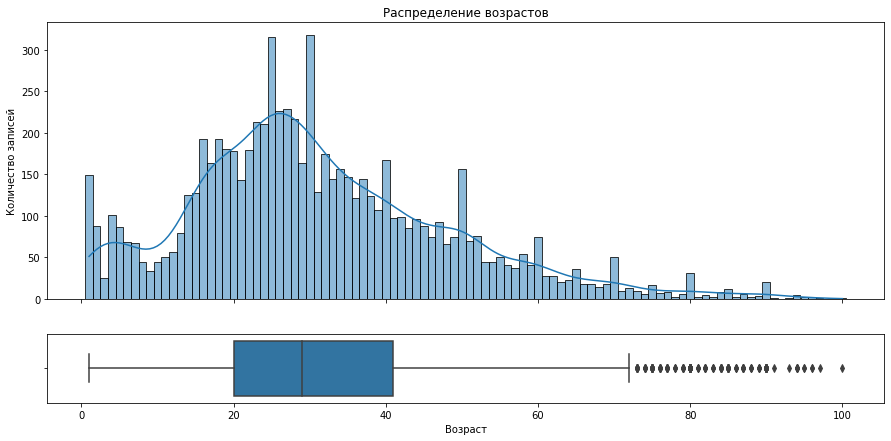

```python
_, [axs_hist, axs_box] = plt.subplots(2, 1,
                                      figsize=(15, 7),
                                      sharex=True,
                                      gridspec_kw=dict(height_ratios=[4,1]))

sns.histplot(data=labels,
             x='real_age',
             bins=labels['real_age'].max(),
             discrete=True,
             kde=True,
             ax=axs_hist)\
.set(title='Распределение возрастов', ylabel='Количество записей')

sns.boxplot(data=labels, x='real_age', ax=axs_box)\
.set(xlabel='Возраст');
```

```python
labels['real_age'].value_counts(ascending=False).head(20)
```

```
30    317
25    315
27    229
26    226
28    217
23    213
24    211
18    193
16    193
19    180
22    179
20    178
32    174
40    167
29    164
17    163
34    156
50    156
1     149
35    147
Name: real_age, dtype: int64
```

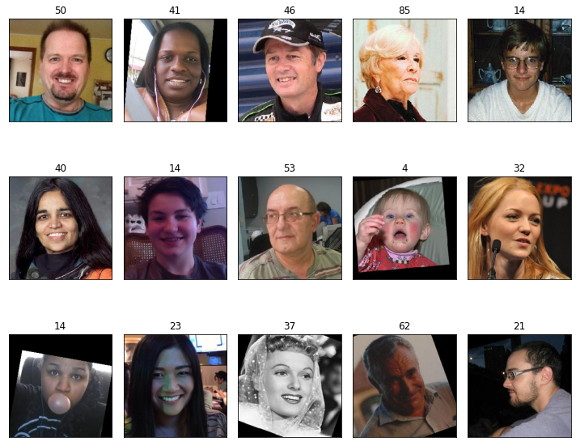

```python
features, target = next(train_gen_flow)

fig = plt.figure(figsize=(10,10))
for i in range(15):
    fig.add_subplot(3, 5, i+1)
    plt.imshow(features[i])
    plt.title(target[i])
    plt.xticks([])
    plt.yticks([])
    plt.tight_layout()
```

**Вывод:**

- Всего 7591 объектов
- Большинство людей в выборке находятся в возрасте от 20 до 40 лет
- В данных присутствуют черно-белые фото и фото под углом

## Обучение модели

(Код в этом разделе запускался в отдельном GPU-тренажёре, поэтому оформлен не как ячейка с кодом, а как код в текстовой ячейке)

```
from tensorflow.keras.preprocessing.image import ImageDataGenerator
from tensorflow.keras.layers import Conv2D, Flatten, Dense, AvgPool2D, GlobalAveragePooling2D
from tensorflow.keras.models import Sequential
from tensorflow.keras.optimizers import Adam
from tensorflow.keras.applications.resnet import ResNet50
import pandas as pd

datagen = ImageDataGenerator(validation_split=0.25, rescale=1./255)
r_seed = 12345

def load_train(path):
    dataframe = pd.read_csv(path + '/labels.csv')
    directory = path +'/final_files'
    train_gen_flow = datagen.flow_from_dataframe(
        dataframe=dataframe,
        directory=directory,
        x_col='file_name',
        y_col='real_age',
        target_size=(224, 224),
        batch_size=32,
        class_mode='raw',
        subset='training',
        seed=r_seed)
    return train_gen_flow

def load_test(path):
    dataframe = pd.read_csv(path + '/labels.csv')
    directory = path +'/final_files'
    test_gen_flow = datagen.flow_from_dataframe(
        dataframe=dataframe,
        directory=directory,
        x_col='file_name',
        y_col='real_age',
        target_size=(224, 224),
        batch_size=32,
        class_mode='raw',
        subset='validation',
        seed=r_seed)
    return test_gen_flow

def create_model(input_shape):
    backbone = ResNet50(input_shape=input_shape,
                    weights='imagenet',
                    include_top=False)

    model = Sequential()
    optimizer = Adam(lr=0.0001)

    model.add(backbone)
    model.add(GlobalAveragePooling2D())
    model.add(Dense(1, activation='relu'))
    model.compile(loss='mean_absolute_error', optimizer=optimizer, metrics=['mean_absolute_error'])

    return model


def train_model(model, train_data, test_data, batch_size=None, epochs=16,
               steps_per_epoch=None, validation_steps=None):
    model.fit(train_data,
              validation_data=test_data,
              batch_size=batch_size, epochs=epochs,
              steps_per_epoch=steps_per_epoch,
              validation_steps=validation_steps,
              verbose=2)

    return model
```

[output not shown]

## Анализ обученной модели

- Была создана нейронная сеть с архитектурой ResNet, с применением сверточных сетей, предобученых на ImageNet
- Обучение модели проходило в 16 эпох с алгоритмом Adam, где learning_rate = 0.0001

Итоговые результаты обучения:

Если использовать полученную модель, то ее достаточно для решения первой задачи (анализировать покупки и предлагать товары, которые могут заинтересовать покупателей определенной возрастной группы). При этом покупателей придется разбивать на группы с шагом не меньше 6 лет.

В случае второй задачи (принятие решение о продаже алкоголя) качества модели недостаточно для возрастной группы от 12 до 24 лет. В остальных возрастных группах использование модели приемлемо